# State List Regression

Variables to test with Effective competition:

**platforms**

-Services -Weapons and Ammunition -Electronics and Communication -Indefinite Delivery Vehicle -Land Vehicles -Aircraft and Drones -Missiles and space -Ships and Submarines

**category unknown**

-Fixed Price Contracts -Indefinite Delivery Vehicle Multi-Award Contracts -Indefinite Delivery Vehicle Single-Award Contracts

**Product Service Codes**

-Aircraft -Land -Missiles and Space -Engines and Power plants -Ships -Facilities Related Services and Construction -Professional, Administrative and Management Support -Other

**Load packages and data:**

```r
require(ggplot2)
require(stringr)
require(plyr)
require(Hmisc)
require(texreg)
options(error=recover)
setwd("K:\\Development\\Competition")
# setwd("C:\\Users\\Greg Sanders\\Documents\\Development\\Fixed-price")
#setwd("C:/Users/scohen/My Documents/Competition/Competition/")
Path<-"K:\\2007-01 PROFESSIONAL SERVICES\\R scripts and data\\"
# Path<-"C:\\Users\\Greg Sanders\\SkyDrive\\Documents\\R Scripts and Data SkyDrive\\"
#path <- "C:/Users/scohen/My Documents/Competition/Competition/"
source(paste(Path,"lookups.r",sep=""))
layout(matrix(c(1,2,3,4),2,2))


StateList  <- read.csv(
    paste("data\\defense_state_competition_combined_2000-2013.csv", sep = ""),
    header = TRUE, sep = ",", dec = ".", strip.white = TRUE,
    na.strings = c("NULL","NA",""),
    stringsAsFactors = TRUE
    )
names(StateList)
```

```
##  [1] "PoPstateCode"              "pNoEffComp"
##  [3] "pEffComp"                  "pPlatOther"
##  [5] "pPlatFnC"                  "pPlatEnC"
##  [7] "pPlatVessel"               "pPlatLand"
##  [9] "pPlatAir"                  "pPlatWnA"
## [11] "pPaltMnS"                  "pPSRServices"
## [13] "pPSRProducts"              "pRnD"
## [15] "pPscPAMS"                  "pPscMED"
## [17] "pPscFRSnC"                 "pPscICT"
## [19] "pPscERS"                   "pPscOther"
## [21] "pPscEnC"                   "pPscLand"
## [23] "pPscEngines"               "pPscAir"
## [25] "pPscCloth"                 "pPscFuels"
## [27] "pPscLnM"                   "pPscRnD"
## [29] "pPscShips"                 "pPscMnS"
```

[output cut: 19 more lines]

```r
StateList <-subset(StateList ,!PoPstateCode %in% c("VI",
"AS",
"MP",
"AE",
"PW",
"US",
"UK",
"GM",
"GB",
"JA",
"ON",
"QC",
"   ",
"BC"))
```

**Correlations of Variables**

```r
rcorr(as.matrix(subset(StateList,select=c(pPSRServices,pPSRProducts, pPlatWnA, pPlatEnC, pIDV, pPlatLand, pPlatAir, pPaltMnS, pPlatVessel, pPlatOther, pRnD, pPriceFixed, pVehMAC, pVehSAC, pPscAir, pPscLand, pPscMnS, pPscEngines, pPscShips, pPscFRSnC, pPscPAMS, pPscOther))))
```

```
##              pPSRServices pPSRProducts pPlatWnA pPlatEnC  pIDV pPlatLand
## pPSRServices         1.00        -0.93    -0.28    -0.09  0.20     -0.38
## pPSRProducts        -0.93         1.00     0.28    -0.02 -0.10      0.47
## pPlatWnA            -0.28         0.28     1.00     0.21 -0.10     -0.06
## pPlatEnC            -0.09        -0.02     0.21     1.00  0.26     -0.15
## pIDV                 0.20        -0.10    -0.10     0.26  1.00      0.30
## pPlatLand           -0.38         0.47    -0.06    -0.15  0.30      1.00
## pPlatAir            -0.48         0.42    -0.02    -0.06 -0.30     -0.12
## pPaltMnS            -0.13        -0.02     0.07     0.04 -0.26     -0.14
## pPlatVessel         -0.22         0.23    -0.15    -0.20 -0.50     -0.09
## pPlatOther           0.46        -0.52    -0.24    -0.04  0.21     -0.24
## pRnD                -0.40         0.05     0.07     0.28 -0.30     -0.14
## pPriceFixed         -0.06         0.31    -0.06    -0.37  0.26      0.18
## pVehMAC              0.43        -0.36    -0.21     0.02  0.58      0.08
## pVehSAC             -0.15         0.24     0.06     0.20  0.77      0.39
## pPscAir             -0.44         0.41     0.05    -0.06 -0.30     -0.13
## pPscLand            -0.38         0.47    -0.06    -0.14  0.32      1.00
## pPscMnS             -0.19         0.17     0.35     0.02 -0.18     -0.13
## pPscEngines         -0.41         0.33    -0.03     0.03 -0.14      0.12
## pPscShips           -0.21         0.23    -0.13    -0.21 -0.50     -0.09
## pPscFRSnC            0.69        -0.56    -0.28    -0.33  0.15     -0.25
## pPscPAMS             0.53        -0.61     0.01     0.32  0.23     -0.25
## pPscOther           -0.02         0.07     0.03     0.12  0.36      0.15
##              pPlatAir pPaltMnS pPlatVessel pPlatOther  pRnD pPriceFixed
## pPSRServices    -0.48    -0.13       -0.22       0.46 -0.40       -0.06
## pPSRProducts     0.42    -0.02        0.23      -0.52  0.05        0.31
## pPlatWnA        -0.02     0.07       -0.15      -0.24  0.07       -0.06
## pPlatEnC        -0.06     0.04       -0.20      -0.04  0.28       -0.37
## pIDV            -0.30    -0.26       -0.50       0.21 -0.30        0.26
## pPlatLand       -0.12    -0.14       -0.09      -0.24 -0.14        0.18
## pPlatAir         1.00    -0.06       -0.01      -0.29  0.26       -0.02
## pPaltMnS        -0.06     1.00       -0.14      -0.02  0.42       -0.34
## pPlatVessel     -0.01    -0.14        1.00      -0.23  0.01        0.00
## pPlatOther      -0.29    -0.02       -0.23       1.00  0.05       -0.37
## pRnD             0.26     0.42        0.01       0.05  1.00       -0.62
## pPriceFixed     -0.02    -0.34        0.00      -0.37 -0.62        1.00
## pVehMAC         -0.37    -0.17       -0.22       0.53 -0.27        0.05
## pVehSAC         -0.08    -0.20       -0.43      -0.17 -0.19        0.33
## pPscAir          0.93    -0.04       -0.08      -0.29  0.17        0.03
## pPscLand        -0.12    -0.16       -0.09      -0.24 -0.14        0.18
```

[output cut: 134 more lines]

```
## pPaltMnS     0.3644    0.3159    0.6485   0.4464
## pPlatVessel  0.0000    0.2452    0.1625   0.0125
## pPlatOther   0.1258    0.7077    0.0000   0.2643
## pRnD         0.9901    0.0004    0.5513   0.3649
## pPriceFixed  0.9214    0.0003    0.0002   0.0330
## pVehMAC      0.1270    0.3597    0.0001   0.6399
## pVehSAC      0.0011    0.5544    0.1534   0.0003
## pPscAir      0.5207    0.0141    0.1182   0.5426
## pPscLand     0.5166    0.0735    0.0700   0.2723
## pPscMnS      0.3700    0.4418    0.1494   0.7433
## pPscEngines  0.7725    0.0095    0.2254   0.8386
## pPscShips              0.2242    0.1927   0.0171
## pPscFRSnC    0.2242              0.6021   0.1622
## pPscPAMS     0.1927    0.6021             0.6342
## pPscOther    0.0171    0.1622    0.6342
```

```r
rcorr(as.matrix(subset(StateList, select=c(pPSRServices, pIDV, pVehSAC))))
```

```
##              pPSRServices pIDV pVehSAC
## pPSRServices         1.00 0.20   -0.15
## pIDV                 0.20 1.00    0.77
## pVehSAC             -0.15 0.77    1.00
##
## n= 53
##
##
## P
##              pPSRServices pIDV   pVehSAC
## pPSRServices              0.1561 0.2878
## pIDV         0.1561              0.0000
## pVehSAC      0.2878       0.0000
```

```r
rcorr(as.matrix(subset(StateList, select=c(pPSRServices, pPscFRSnC, pPscPAMS))))
```

```
##              pPSRServices pPscFRSnC pPscPAMS
## pPSRServices         1.00      0.69     0.53
## pPscFRSnC            0.69      1.00    -0.07
## pPscPAMS             0.53     -0.07     1.00
##
## n= 53
##
##
## P
##              pPSRServices pPscFRSnC pPscPAMS
## pPSRServices              0.0000    0.0000
## pPscFRSnC    0.0000                 0.6021
## pPscPAMS     0.0000       0.6021
```

**Regressions**

Services:

```r
model1 <- lm(pEffComp ~ pPSRServices, data = StateList)
summary(model1)
```

```
##
## Call:
## lm(formula = pEffComp ~ pPSRServices, data = StateList)
##
## Residuals:
##       Min        1Q    Median        3Q       Max
## -0.256329 -0.062562 -0.008726  0.060282  0.235447
##
## Coefficients:
##              Estimate Std. Error t value Pr(>|t|)
## (Intercept)   0.72152    0.03435  21.007  < 2e-16 ***
## pPSRServices -0.58392    0.06725  -8.683 1.27e-11 ***
## ---
## Signif. codes:  0 '***' 0.001 '**' 0.01 '*' 0.05 '.' 0.1 ' ' 1
##
## Residual standard error: 0.1073 on 51 degrees of freedom
## Multiple R-squared:  0.5965, Adjusted R-squared:  0.5886
## F-statistic: 75.39 on 1 and 51 DF,  p-value: 1.266e-11
```

```r
screenreg(list(model1))
```

```
##
## =======================
##               Model 1
## -----------------------
## (Intercept)    0.72 ***
##               (0.03)
## pPSRServices  -0.58 ***
##               (0.07)
## -----------------------
## R^2            0.60
## Adj. R^2       0.59
## Num. obs.     53
## RMSE           0.11
## =======================
## *** p < 0.001, ** p < 0.01, * p < 0.05
```

weapons and Ammunition Platform:

```r
model2 <- lm(pEffComp ~ pPSRServices+ pPlatWnA, data = StateList)
summary(model2)
```

```
##
## Call:
## lm(formula = pEffComp ~ pPSRServices + pPlatWnA, data = StateList)
##
## Residuals:
##      Min       1Q   Median       3Q      Max
## -0.26552 -0.06550 -0.01089  0.05987  0.22129
##
## Coefficients:
##              Estimate Std. Error t value Pr(>|t|)
## (Intercept)   0.73950    0.03932  18.807  < 2e-16 ***
## pPSRServices -0.60244    0.07014  -8.590 2.07e-11 ***
## pPlatWnA     -0.15989    0.16968  -0.942    0.351
## ---
## Signif. codes:  0 '***' 0.001 '**' 0.01 '*' 0.05 '.' 0.1 ' ' 1
##
## Residual standard error: 0.1075 on 50 degrees of freedom
## Multiple R-squared:  0.6035, Adjusted R-squared:  0.5877
## F-statistic: 38.06 on 2 and 50 DF,  p-value: 9.025e-11
```

```r
screenreg(list(model1, model2))
```

```
##
## ==================================
##               Model 1    Model 2
## ----------------------------------
## (Intercept)    0.72 ***   0.74 ***
##               (0.03)     (0.04)
## pPSRServices  -0.58 ***  -0.60 ***
##               (0.07)     (0.07)
## pPlatWnA                 -0.16
##                          (0.17)
## ----------------------------------
## R^2            0.60       0.60
## Adj. R^2       0.59       0.59
## Num. obs.     53         53
## RMSE           0.11       0.11
## ==================================
## *** p < 0.001, ** p < 0.01, * p < 0.05
```

Observations: WnA does does not change R^2, is not significant and only decreases the coefficient on Services by .02. –>won’t be included in the model.

**Electronics and Communication platform:**

```r
model3 <- lm(pEffComp ~ pPSRServices+ pPlatEnC, data = StateList)
summary(model3)
```

```
##
## Call:
## lm(formula = pEffComp ~ pPSRServices + pPlatEnC, data = StateList)
##
## Residuals:
##       Min        1Q    Median        3Q       Max
## -0.248016 -0.062381 -0.006958  0.070299  0.256422
##
## Coefficients:
##              Estimate Std. Error t value Pr(>|t|)
## (Intercept)   0.69565    0.04037  17.232  < 2e-16 ***
## pPSRServices -0.57686    0.06721  -8.583 2.11e-11 ***
## pPlatEnC      0.17808    0.14771   1.206    0.234
## ---
## Signif. codes:  0 '***' 0.001 '**' 0.01 '*' 0.05 '.' 0.1 ' ' 1
##
## Residual standard error: 0.1069 on 50 degrees of freedom
## Multiple R-squared:  0.6079, Adjusted R-squared:  0.5922
## F-statistic: 38.76 on 2 and 50 DF,  p-value: 6.846e-11
```

```r
screenreg(list(model1, model3))
```

```
##
## ==================================
##               Model 1    Model 2
## ----------------------------------
## (Intercept)    0.72 ***   0.70 ***
##               (0.03)     (0.04)
## pPSRServices  -0.58 ***  -0.58 ***
##               (0.07)     (0.07)
## pPlatEnC                  0.18
##                          (0.15)
## ----------------------------------
## R^2            0.60       0.61
## Adj. R^2       0.59       0.59
## Num. obs.     53         53
## RMSE           0.11       0.11
## ==================================
## *** p < 0.001, ** p < 0.01, * p < 0.05
```

**Observations** EnC does not change adjusted r^2, increases r^2 by .01 and does not affect coefficietn on Services. Will not be included in the model.

**IDV platform:**

```r
model4 <- lm(pEffComp ~ pPSRServices+ pIDV, data = StateList)
summary(model4)
```

```
##
## Call:
## lm(formula = pEffComp ~ pPSRServices + pIDV, data = StateList)
##
## Residuals:
##       Min        1Q    Median        3Q       Max
## -0.268456 -0.065255  0.002615  0.049502  0.202559
##
## Coefficients:
##              Estimate Std. Error t value Pr(>|t|)
## (Intercept)   0.79931    0.05617  14.230  < 2e-16 ***
## pPSRServices -0.56090    0.06730  -8.334 5.08e-11 ***
## pIDV         -0.17251    0.09967  -1.731   0.0896 .
## ---
## Signif. codes:  0 '***' 0.001 '**' 0.01 '*' 0.05 '.' 0.1 ' ' 1
##
## Residual standard error: 0.1053 on 50 degrees of freedom
## Multiple R-squared:  0.6193, Adjusted R-squared:  0.6041
## F-statistic: 40.67 on 2 and 50 DF,  p-value: 3.272e-11
```

```r
screenreg(list(model1, model4))
```

```
##
## ==================================
##               Model 1    Model 2
## ----------------------------------
## (Intercept)    0.72 ***   0.80 ***
##               (0.03)     (0.06)
## pPSRServices  -0.58 ***  -0.56 ***
##               (0.07)     (0.07)
## pIDV                     -0.17
##                          (0.10)
## ----------------------------------
## R^2            0.60       0.62
## Adj. R^2       0.59       0.60
## Num. obs.     53         53
## RMSE           0.11       0.11
## ==================================
## *** p < 0.001, ** p < 0.01, * p < 0.05
```

```r
model5 <- lm(pEffComp ~ pPSRServices+ pIDV+ I(pIDV^2), data = StateList)
summary(model5)
```

```
##
## Call:
## lm(formula = pEffComp ~ pPSRServices + pIDV + I(pIDV^2), data = StateList)
##
## Residuals:
##       Min        1Q    Median        3Q       Max
## -0.280373 -0.063993  0.007433  0.056867  0.211401
##
## Coefficients:
##              Estimate Std. Error t value Pr(>|t|)
## (Intercept)   0.68316    0.12525   5.454 1.60e-06 ***
## pPSRServices -0.57430    0.06848  -8.387 4.93e-11 ***
## pIDV          0.38070    0.54248   0.702    0.486
## I(pIDV^2)    -0.56642    0.54599  -1.037    0.305
## ---
## Signif. codes:  0 '***' 0.001 '**' 0.01 '*' 0.05 '.' 0.1 ' ' 1
##
## Residual standard error: 0.1052 on 49 degrees of freedom
## Multiple R-squared:  0.6275, Adjusted R-squared:  0.6047
## F-statistic: 27.51 on 3 and 49 DF,  p-value: 1.415e-10
```

```r
screenreg(list(model1, model4, model5))
```

```
##
## =============================================
##               Model 1    Model 2    Model 3
## ---------------------------------------------
## (Intercept)    0.72 ***   0.80 ***   0.68 ***
##               (0.03)     (0.06)     (0.13)
## pPSRServices  -0.58 ***  -0.56 ***  -0.57 ***
##               (0.07)     (0.07)     (0.07)
## pIDV                     -0.17       0.38
##                          (0.10)     (0.54)
## I(pIDV^2)                           -0.57
##                                     (0.55)
## ---------------------------------------------
## R^2            0.60       0.62       0.63
## Adj. R^2       0.59       0.60       0.60
## Num. obs.     53         53         53
## RMSE           0.11       0.11       0.11
## =============================================
## *** p < 0.001, ** p < 0.01, * p < 0.05
```

**Land Vehicles platform**

```r
model6 <- lm(pEffComp ~ pPSRServices+ pIDV+ pPlatLand, data = StateList)
summary(model6)
```

```
##
## Call:
## lm(formula = pEffComp ~ pPSRServices + pIDV + pPlatLand, data = StateList)
##
## Residuals:
##       Min        1Q    Median        3Q       Max
## -0.267167 -0.060226  0.002844  0.058146  0.205707
##
## Coefficients:
##              Estimate Std. Error t value Pr(>|t|)
## (Intercept)   0.79912    0.05666  14.103  < 2e-16 ***
## pPSRServices -0.54713    0.07705  -7.101 4.63e-09 ***
## pIDV         -0.18996    0.11063  -1.717   0.0923 .
## pPlatLand     0.04797    0.12695   0.378   0.7072
## ---
## Signif. codes:  0 '***' 0.001 '**' 0.01 '*' 0.05 '.' 0.1 ' ' 1
##
## Residual standard error: 0.1062 on 49 degrees of freedom
## Multiple R-squared:  0.6204, Adjusted R-squared:  0.5972
## F-statistic: 26.69 on 3 and 49 DF,  p-value: 2.231e-10
```

```r
screenreg(list(model1, model4, model6))
```

```
##
## =============================================
##               Model 1    Model 2    Model 3
## ---------------------------------------------
## (Intercept)    0.72 ***   0.80 ***   0.80 ***
##               (0.03)     (0.06)     (0.06)
## pPSRServices  -0.58 ***  -0.56 ***  -0.55 ***
##               (0.07)     (0.07)     (0.08)
## pIDV                     -0.17      -0.19
##                          (0.10)     (0.11)
## pPlatLand                            0.05
##                                     (0.13)
## ---------------------------------------------
## R^2            0.60       0.62       0.62
## Adj. R^2       0.59       0.60       0.60
## Num. obs.     53         53         53
## RMSE           0.11       0.11       0.11
## =============================================
## *** p < 0.001, ** p < 0.01, * p < 0.05
```

**Observations** pPlatLand does not affect the model in an meaningful way. it increases SErvices by .01, doesn’t change r^2 and is not significant itself.

**Aircraft and Drones platform**

```r
model7 <- lm(pEffComp ~ pPSRServices+ pIDV+ pPlatAir, data = StateList)
summary(model7)
```

```
##
## Call:
## lm(formula = pEffComp ~ pPSRServices + pIDV + pPlatAir, data = StateList)
##
## Residuals:
##       Min        1Q    Median        3Q       Max
## -0.240190 -0.048732 -0.001341  0.064577  0.179911
##
## Coefficients:
##              Estimate Std. Error t value Pr(>|t|)
## (Intercept)   0.67830    0.06457  10.505 3.83e-14 ***
## pPSRServices -0.46423    0.06927  -6.702 1.92e-08 ***
## pIDV         -0.10074    0.09468  -1.064  0.29253
## pPlatAir      0.32919    0.10494   3.137  0.00289 **
## ---
## Signif. codes:  0 '***' 0.001 '**' 0.01 '*' 0.05 '.' 0.1 ' ' 1
##
## Residual standard error: 0.09706 on 49 degrees of freedom
## Multiple R-squared:  0.683,  Adjusted R-squared:  0.6636
## F-statistic: 35.19 on 3 and 49 DF,  p-value: 2.831e-12
```

```r
screenreg(list(model1, model4, model7))
```

```
##
## =============================================
##               Model 1    Model 2    Model 3
## ---------------------------------------------
## (Intercept)    0.72 ***   0.80 ***   0.68 ***
##               (0.03)     (0.06)     (0.06)
## pPSRServices  -0.58 ***  -0.56 ***  -0.46 ***
##               (0.07)     (0.07)     (0.07)
## pIDV                     -0.17      -0.10
##                          (0.10)     (0.09)
## pPlatAir                             0.33 **
##                                     (0.10)
## ---------------------------------------------
## R^2            0.60       0.62       0.68
## Adj. R^2       0.59       0.60       0.66
## Num. obs.     53         53         53
## RMSE           0.11       0.11       0.10
## =============================================
## *** p < 0.001, ** p < 0.01, * p < 0.05
```

**Observations:** air increases significnace, it is signiciant, decreases services by .1 and increases r^ by .06. will be included.

**Missiles and Space Platform**

```r
model8 <- lm(pEffComp ~ pPSRServices+ pIDV+ pPlatAir+ pPaltMnS, data = StateList)
summary(model8)
```

```
##
## Call:
## lm(formula = pEffComp ~ pPSRServices + pIDV + pPlatAir + pPaltMnS,
##     data = StateList)
##
## Residuals:
##       Min        1Q    Median        3Q       Max
## -0.245307 -0.056430 -0.000046  0.067821  0.181619
##
## Coefficients:
##              Estimate Std. Error t value Pr(>|t|)
## (Intercept)   0.66190    0.07204   9.188 3.76e-12 ***
## pPSRServices -0.45809    0.07074  -6.476 4.69e-08 ***
## pIDV         -0.08548    0.09965  -0.858  0.39527
## pPlatAir      0.34092    0.10802   3.156  0.00276 **
## pPaltMnS      0.11066    0.20898   0.530  0.59888
## ---
## Signif. codes:  0 '***' 0.001 '**' 0.01 '*' 0.05 '.' 0.1 ' ' 1
##
## Residual standard error: 0.09778 on 48 degrees of freedom
## Multiple R-squared:  0.6848, Adjusted R-squared:  0.6585
## F-statistic: 26.07 on 4 and 48 DF,  p-value: 1.612e-11
```

```r
screenreg(list(model1, model4, model7, model8))
```

```
##
## ========================================================
##               Model 1    Model 2    Model 3    Model 4
## --------------------------------------------------------
## (Intercept)    0.72 ***   0.80 ***   0.68 ***   0.66 ***
##               (0.03)     (0.06)     (0.06)     (0.07)
## pPSRServices  -0.58 ***  -0.56 ***  -0.46 ***  -0.46 ***
##               (0.07)     (0.07)     (0.07)     (0.07)
## pIDV                     -0.17      -0.10      -0.09
##                          (0.10)     (0.09)     (0.10)
## pPlatAir                             0.33 **    0.34 **
##                                     (0.10)     (0.11)
## pPaltMnS                                        0.11
##                                                (0.21)
## --------------------------------------------------------
## R^2            0.60       0.62       0.68       0.68
## Adj. R^2       0.59       0.60       0.66       0.66
## Num. obs.     53         53         53         53
## RMSE           0.11       0.11       0.10       0.10
## ========================================================
## *** p < 0.001, ** p < 0.01, * p < 0.05
```

**Observations:** Missiles and Space platform is not statisticaly significant, does not change other cofeficients and does not affect r^2, MnS will not be included

**Ships and Submarines Platform**

```r
model9 <- lm(pEffComp ~ pPSRServices+ pIDV+ pPlatAir+ pPlatVessel, data = StateList)
summary(model9)
```

```
##
## Call:
## lm(formula = pEffComp ~ pPSRServices + pIDV + pPlatAir + pPlatVessel,
##     data = StateList)
##
## Residuals:
##      Min       1Q   Median       3Q      Max
## -0.23840 -0.04963 -0.00105  0.06644  0.17673
##
## Coefficients:
##              Estimate Std. Error t value Pr(>|t|)
## (Intercept)   0.66694    0.08137   8.196 1.11e-10 ***
## pPSRServices -0.45995    0.07232  -6.360 7.05e-08 ***
## pIDV         -0.08703    0.11224  -0.775  0.44193
## pPlatAir      0.33653    0.11055   3.044  0.00378 **
## pPlatVessel   0.02960    0.12691   0.233  0.81659
## ---
## Signif. codes:  0 '***' 0.001 '**' 0.01 '*' 0.05 '.' 0.1 ' ' 1
##
## Residual standard error: 0.09801 on 48 degrees of freedom
## Multiple R-squared:  0.6833, Adjusted R-squared:  0.6569
## F-statistic: 25.89 on 4 and 48 DF,  p-value: 1.801e-11
```

```r
screenreg(list(model1, model4, model7, model9))
```

```
##
## ========================================================
##               Model 1    Model 2    Model 3    Model 4
## --------------------------------------------------------
## (Intercept)    0.72 ***   0.80 ***   0.68 ***   0.67 ***
##               (0.03)     (0.06)     (0.06)     (0.08)
## pPSRServices  -0.58 ***  -0.56 ***  -0.46 ***  -0.46 ***
##               (0.07)     (0.07)     (0.07)     (0.07)
## pIDV                     -0.17      -0.10      -0.09
##                          (0.10)     (0.09)     (0.11)
## pPlatAir                             0.33 **    0.34 **
##                                     (0.10)     (0.11)
## pPlatVessel                                     0.03
##                                                (0.13)
## --------------------------------------------------------
## R^2            0.60       0.62       0.68       0.68
## Adj. R^2       0.59       0.60       0.66       0.66
## Num. obs.     53         53         53         53
## RMSE           0.11       0.11       0.10       0.10
## ========================================================
## *** p < 0.001, ** p < 0.01, * p < 0.05
```

**Observations** Ships and Submarines Platform does not impact the model nad is not statistically significant and will not be included

**Other Platforms**

```r
model10 <- lm(pEffComp ~ pPSRServices+ pIDV+ pPlatAir+ pPlatOther, data = StateList)
summary(model10)
```

```
##
## Call:
## lm(formula = pEffComp ~ pPSRServices + pIDV + pPlatAir + pPlatOther,
##     data = StateList)
##
## Residuals:
##       Min        1Q    Median        3Q       Max
## -0.219310 -0.059922 -0.004586  0.064184  0.191624
##
## Coefficients:
##              Estimate Std. Error t value Pr(>|t|)
## (Intercept)   0.68678    0.06603  10.401 6.88e-14 ***
## pPSRServices -0.44444    0.07515  -5.914 3.39e-07 ***
## pIDV         -0.09275    0.09586  -0.968  0.33808
## pPlatAir      0.32471    0.10568   3.073  0.00349 **
## pPlatOther   -0.07414    0.10586  -0.700  0.48708
## ---
## Signif. codes:  0 '***' 0.001 '**' 0.01 '*' 0.05 '.' 0.1 ' ' 1
##
## Residual standard error: 0.09757 on 48 degrees of freedom
## Multiple R-squared:  0.6862, Adjusted R-squared:   0.66
## F-statistic: 26.24 on 4 and 48 DF,  p-value: 1.455e-11
```

```r
screenreg(list(model1, model4, model7, model10))
```

```
##
## ========================================================
##               Model 1    Model 2    Model 3    Model 4
## --------------------------------------------------------
## (Intercept)    0.72 ***   0.80 ***   0.68 ***   0.69 ***
##               (0.03)     (0.06)     (0.06)     (0.07)
## pPSRServices  -0.58 ***  -0.56 ***  -0.46 ***  -0.44 ***
##               (0.07)     (0.07)     (0.07)     (0.08)
## pIDV                     -0.17      -0.10      -0.09
##                          (0.10)     (0.09)     (0.10)
## pPlatAir                             0.33 **    0.32 **
##                                     (0.10)     (0.11)
## pPlatOther                                     -0.07
##                                                (0.11)
## --------------------------------------------------------
## R^2            0.60       0.62       0.68       0.69
## Adj. R^2       0.59       0.60       0.66       0.66
## Num. obs.     53         53         53         53
## RMSE           0.11       0.11       0.10       0.10
## ========================================================
## *** p < 0.001, ** p < 0.01, * p < 0.05
```

**Observations:** Other platform does is not significant, only increases r^1 by .01, (not adjusted r^2 at all) and increases Services by .02. Will not be included in the model.

**Research and Development**

```r
model11 <- lm(pEffComp ~ pPSRServices+ pIDV+ pPlatAir+ pRnD, data = StateList)
summary(model11)
```

```
##
## Call:
## lm(formula = pEffComp ~ pPSRServices + pIDV + pPlatAir + pRnD,
##     data = StateList)
##
## Residuals:
##       Min        1Q    Median        3Q       Max
## -0.265941 -0.046030 -0.001315  0.064888  0.177579
##
## Coefficients:
##              Estimate Std. Error t value Pr(>|t|)
## (Intercept)   0.65947    0.07636   8.637 2.45e-11 ***
## pPSRServices -0.45306    0.07374  -6.144 1.51e-07 ***
## pIDV         -0.08978    0.09823  -0.914  0.36531
## pPlatAir      0.32793    0.10582   3.099  0.00324 **
## pRnD          0.09097    0.19288   0.472  0.63933
## ---
## Signif. codes:  0 '***' 0.001 '**' 0.01 '*' 0.05 '.' 0.1 ' ' 1
##
## Residual standard error: 0.09784 on 48 degrees of freedom
## Multiple R-squared:  0.6844, Adjusted R-squared:  0.6581
## F-statistic: 26.03 on 4 and 48 DF,  p-value: 1.658e-11
```

```r
screenreg(list(model1, model4, model7, model11))
```

```
##
## ========================================================
##               Model 1    Model 2    Model 3    Model 4
## --------------------------------------------------------
## (Intercept)    0.72 ***   0.80 ***   0.68 ***   0.66 ***
##               (0.03)     (0.06)     (0.06)     (0.08)
## pPSRServices  -0.58 ***  -0.56 ***  -0.46 ***  -0.45 ***
##               (0.07)     (0.07)     (0.07)     (0.07)
## pIDV                     -0.17      -0.10      -0.09
##                          (0.10)     (0.09)     (0.10)
## pPlatAir                             0.33 **    0.33 **
##                                     (0.10)     (0.11)
## pRnD                                            0.09
##                                                (0.19)
## --------------------------------------------------------
## R^2            0.60       0.62       0.68       0.68
## Adj. R^2       0.59       0.60       0.66       0.66
## Num. obs.     53         53         53         53
## RMSE           0.11       0.11       0.10       0.10
## ========================================================
## *** p < 0.001, ** p < 0.01, * p < 0.05
```

**Observations** RnD is not statistically significant, does not change r^2 or adjusted and only increases services by .01. Will not be included in the model.

**Fixed Price Contracts**

```r
model12 <- lm(pEffComp ~ pPSRServices+ pIDV+ pPlatAir+ pPriceFixed, data = StateList)
summary(model12)
```

```
##
## Call:
## lm(formula = pEffComp ~ pPSRServices + pIDV + pPlatAir + pPriceFixed,
##     data = StateList)
##
## Residuals:
##       Min        1Q    Median        3Q       Max
## -0.284915 -0.050105 -0.000563  0.062284  0.157482
##
## Coefficients:
##              Estimate Std. Error t value Pr(>|t|)
## (Intercept)   0.77040    0.08642   8.915 9.47e-12 ***
## pPSRServices -0.47546    0.06862  -6.929 9.45e-09 ***
## pIDV         -0.05824    0.09711  -0.600  0.55153
## pPlatAir      0.33105    0.10340   3.202  0.00243 **
## pPriceFixed  -0.14728    0.09352  -1.575  0.12189
## ---
## Signif. codes:  0 '***' 0.001 '**' 0.01 '*' 0.05 '.' 0.1 ' ' 1
##
## Residual standard error: 0.09563 on 48 degrees of freedom
## Multiple R-squared:  0.6985, Adjusted R-squared:  0.6734
## F-statistic: 27.81 on 4 and 48 DF,  p-value: 5.639e-12
```

```r
screenreg(list(model1, model4, model7, model12))
```

```
##
## ========================================================
##               Model 1    Model 2    Model 3    Model 4
## --------------------------------------------------------
## (Intercept)    0.72 ***   0.80 ***   0.68 ***   0.77 ***
##               (0.03)     (0.06)     (0.06)     (0.09)
## pPSRServices  -0.58 ***  -0.56 ***  -0.46 ***  -0.48 ***
##               (0.07)     (0.07)     (0.07)     (0.07)
## pIDV                     -0.17      -0.10      -0.06
##                          (0.10)     (0.09)     (0.10)
## pPlatAir                             0.33 **    0.33 **
##                                     (0.10)     (0.10)
## pPriceFixed                                    -0.15
##                                                (0.09)
## --------------------------------------------------------
## R^2            0.60       0.62       0.68       0.70
## Adj. R^2       0.59       0.60       0.66       0.67
## Num. obs.     53         53         53         53
## RMSE           0.11       0.11       0.10       0.10
## ========================================================
## *** p < 0.001, ** p < 0.01, * p < 0.05
```

```r
model13 <- lm(pEffComp ~ pPSRServices+ pIDV+ pPlatAir+ pPriceFixed+ I(pPriceFixed^2), data = StateList)
summary(model13)
```

```
##
## Call:
## lm(formula = pEffComp ~ pPSRServices + pIDV + pPlatAir + pPriceFixed +
##     I(pPriceFixed^2), data = StateList)
##
## Residuals:
##       Min        1Q    Median        3Q       Max
## -0.201613 -0.050065 -0.002279  0.058333  0.159110
##
## Coefficients:
##                  Estimate Std. Error t value Pr(>|t|)
## (Intercept)       0.09645    0.29408   0.328   0.7444
## pPSRServices     -0.47362    0.06549  -7.232 3.64e-09 ***
## pIDV             -0.05009    0.09274  -0.540   0.5917
## pPlatAir          0.24067    0.10569   2.277   0.0274 *
## pPriceFixed       1.86769    0.84865   2.201   0.0327 *
## I(pPriceFixed^2) -1.42550    0.59705  -2.388   0.0210 *
## ---
## Signif. codes:  0 '***' 0.001 '**' 0.01 '*' 0.05 '.' 0.1 ' ' 1
##
## Residual standard error: 0.09127 on 47 degrees of freedom
## Multiple R-squared:  0.7311, Adjusted R-squared:  0.7025
## F-statistic: 25.56 on 5 and 47 DF,  p-value: 2.323e-12
```

```r
screenreg(list(model1, model4, model7, model12, model13))
```

```
##
## =======================================================================
##                   Model 1    Model 2    Model 3    Model 4    Model 5
## -----------------------------------------------------------------------
## (Intercept)        0.72 ***   0.80 ***   0.68 ***   0.77 ***   0.10
##                   (0.03)     (0.06)     (0.06)     (0.09)     (0.29)
## pPSRServices      -0.58 ***  -0.56 ***  -0.46 ***  -0.48 ***  -0.47 ***
##                   (0.07)     (0.07)     (0.07)     (0.07)     (0.07)
## pIDV                         -0.17      -0.10      -0.06      -0.05
##                              (0.10)     (0.09)     (0.10)     (0.09)
## pPlatAir                                 0.33 **    0.33 **    0.24 *
##                                         (0.10)     (0.10)     (0.11)
## pPriceFixed                                        -0.15       1.87 *
##                                                    (0.09)     (0.85)
## I(pPriceFixed^2)                                              -1.43 *
##                                                               (0.60)
## -----------------------------------------------------------------------
## R^2                0.60       0.62       0.68       0.70       0.73
## Adj. R^2           0.59       0.60       0.66       0.67       0.70
## Num. obs.         53         53         53         53         53
## RMSE               0.11       0.11       0.10       0.10       0.09
## =======================================================================
## *** p < 0.001, ** p < 0.01, * p < 0.05
```

**Indefinite Delivery Vehicle Multi-award contracts**

```r
model14 <- lm(pEffComp ~ pPSRServices+ pIDV+ pPlatAir+ pPriceFixed+ I(pPriceFixed^2)+ pVehMAC, data = StateList)
summary(model14)
```

```
##
## Call:
## lm(formula = pEffComp ~ pPSRServices + pIDV + pPlatAir + pPriceFixed +
##     I(pPriceFixed^2) + pVehMAC, data = StateList)
##
## Residuals:
##      Min       1Q   Median       3Q      Max
## -0.19695 -0.05246  0.00458  0.06653  0.15877
##
## Coefficients:
##                  Estimate Std. Error t value Pr(>|t|)
## (Intercept)       0.07530    0.29653   0.254   0.8007
## pPSRServices     -0.49093    0.06938  -7.076    7e-09 ***
## pIDV             -0.09591    0.10998  -0.872   0.3877
## pPlatAir          0.24412    0.10622   2.298   0.0261 *
## pPriceFixed       1.96130    0.86050   2.279   0.0273 *
## I(pPriceFixed^2) -1.48756    0.60474  -2.460   0.0177 *
## pVehMAC           0.15280    0.19507   0.783   0.4375
## ---
## Signif. codes:  0 '***' 0.001 '**' 0.01 '*' 0.05 '.' 0.1 ' ' 1
##
## Residual standard error: 0.09164 on 46 degrees of freedom
## Multiple R-squared:  0.7347, Adjusted R-squared:  0.7001
## F-statistic: 21.23 on 6 and 46 DF,  p-value: 9.31e-12
```

```r
screenreg(list(model1, model4, model7, model12, model13, model14))
```

```
##
## ==================================================================================
##                   Model 1    Model 2    Model 3    Model 4    Model 5    Model 6
## ----------------------------------------------------------------------------------
## (Intercept)        0.72 ***   0.80 ***   0.68 ***   0.77 ***   0.10       0.08
##                   (0.03)     (0.06)     (0.06)     (0.09)     (0.29)     (0.30)
## pPSRServices      -0.58 ***  -0.56 ***  -0.46 ***  -0.48 ***  -0.47 ***  -0.49 ***
##                   (0.07)     (0.07)     (0.07)     (0.07)     (0.07)     (0.07)
## pIDV                         -0.17      -0.10      -0.06      -0.05      -0.10
##                              (0.10)     (0.09)     (0.10)     (0.09)     (0.11)
## pPlatAir                                 0.33 **    0.33 **    0.24 *     0.24 *
##                                         (0.10)     (0.10)     (0.11)     (0.11)
## pPriceFixed                                        -0.15       1.87 *     1.96 *
##                                                    (0.09)     (0.85)     (0.86)
## I(pPriceFixed^2)                                              -1.43 *    -1.49 *
##                                                               (0.60)     (0.60)
## pVehMAC                                                                   0.15
##                                                                          (0.20)
## ----------------------------------------------------------------------------------
## R^2                0.60       0.62       0.68       0.70       0.73       0.73
## Adj. R^2           0.59       0.60       0.66       0.67       0.70       0.70
## Num. obs.         53         53         53         53         53         53
## RMSE               0.11       0.11       0.10       0.10       0.09       0.09
## ==================================================================================
## *** p < 0.001, ** p < 0.01, * p < 0.05
```

**Observations** IDV MAC is not statistically significant, it does not change r^2, it decreases services by .02 but will not be continued in the model.

**IDV single-award contracts**

```r
model15 <- lm(pEffComp ~ pPSRServices+ pPlatAir+ pIDV+ pPriceFixed+ I(pPriceFixed^2)+ pVehSAC, data = StateList)
summary(model15)
```

```
##
## Call:
## lm(formula = pEffComp ~ pPSRServices + pPlatAir + pIDV + pPriceFixed +
##     I(pPriceFixed^2) + pVehSAC, data = StateList)
##
## Residuals:
##       Min        1Q    Median        3Q       Max
## -0.194328 -0.047820 -0.000322  0.071711  0.160246
##
## Coefficients:
##                  Estimate Std. Error t value Pr(>|t|)
## (Intercept)       0.08105    0.29220   0.277   0.7827
## pPSRServices     -0.51242    0.07156  -7.161 5.23e-09 ***
## pPlatAir          0.24223    0.10493   2.308   0.0255 *
## pIDV              0.11131    0.15470   0.719   0.4755
## pPriceFixed       1.97386    0.84649   2.332   0.0241 *
## I(pPriceFixed^2) -1.48670    0.59462  -2.500   0.0160 *
## pVehSAC          -0.26714    0.20577  -1.298   0.2007
## ---
## Signif. codes:  0 '***' 0.001 '**' 0.01 '*' 0.05 '.' 0.1 ' ' 1
##
## Residual standard error: 0.09061 on 46 degrees of freedom
## Multiple R-squared:  0.7406, Adjusted R-squared:  0.7068
## F-statistic: 21.89 on 6 and 46 DF,  p-value: 5.604e-12
```

```r
screenreg(list(model1, model4, model7, model12, model13, model15))
```

```
##
## ==================================================================================
##                   Model 1    Model 2    Model 3    Model 4    Model 5    Model 6
## ----------------------------------------------------------------------------------
## (Intercept)        0.72 ***   0.80 ***   0.68 ***   0.77 ***   0.10       0.08
##                   (0.03)     (0.06)     (0.06)     (0.09)     (0.29)     (0.29)
## pPSRServices      -0.58 ***  -0.56 ***  -0.46 ***  -0.48 ***  -0.47 ***  -0.51 ***
##                   (0.07)     (0.07)     (0.07)     (0.07)     (0.07)     (0.07)
## pIDV                         -0.17      -0.10      -0.06      -0.05       0.11
##                              (0.10)     (0.09)     (0.10)     (0.09)     (0.15)
## pPlatAir                                 0.33 **    0.33 **    0.24 *     0.24 *
##                                         (0.10)     (0.10)     (0.11)     (0.10)
## pPriceFixed                                        -0.15       1.87 *     1.97 *
##                                                    (0.09)     (0.85)     (0.85)
## I(pPriceFixed^2)                                              -1.43 *    -1.49 *
##                                                               (0.60)     (0.59)
## pVehSAC                                                                  -0.27
##                                                                          (0.21)
## ----------------------------------------------------------------------------------
## R^2                0.60       0.62       0.68       0.70       0.73       0.74
## Adj. R^2           0.59       0.60       0.66       0.67       0.70       0.71
## Num. obs.         53         53         53         53         53         53
## RMSE               0.11       0.11       0.10       0.10       0.09       0.09
## ==================================================================================
## *** p < 0.001, ** p < 0.01, * p < 0.05
```

**Observations** IDV SAC decreases the coefficient on Services by .04, the one on Fixed price by .06 and increases r^2 by .01. Itself is not statistically significant (p value = .20). will not be included in the model.

**PSC Air**

```r
model16 <- lm(pEffComp ~ pPSRServices+ pPlatAir+ pIDV+ pPriceFixed+ I(pPriceFixed^2)+ pPscAir, data = StateList)
summary(model16)
```

```
##
## Call:
## lm(formula = pEffComp ~ pPSRServices + pPlatAir + pIDV + pPriceFixed +
##     I(pPriceFixed^2) + pPscAir, data = StateList)
##
## Residuals:
##       Min        1Q    Median        3Q       Max
## -0.210490 -0.050095 -0.002867  0.056299  0.153393
##
## Coefficients:
##                  Estimate Std. Error t value Pr(>|t|)
## (Intercept)       0.11515    0.29472   0.391   0.6978
## pPSRServices     -0.47170    0.06553  -7.198  4.6e-09 ***
## pPlatAir          0.46769    0.25171   1.858   0.0696 .
## pIDV             -0.05811    0.09310  -0.624   0.5356
## pPriceFixed       1.79936    0.85155   2.113   0.0401 *
## I(pPriceFixed^2) -1.36727    0.60000  -2.279   0.0274 *
## pPscAir          -0.30725    0.30917  -0.994   0.3255
## ---
## Signif. codes:  0 '***' 0.001 '**' 0.01 '*' 0.05 '.' 0.1 ' ' 1
##
## Residual standard error: 0.09128 on 46 degrees of freedom
## Multiple R-squared:  0.7368, Adjusted R-squared:  0.7025
## F-statistic: 21.46 on 6 and 46 DF,  p-value: 7.789e-12
```

```r
screenreg(list(model1, model4, model7, model12, model13, model16))
```

```
##
## ==================================================================================
##                   Model 1    Model 2    Model 3    Model 4    Model 5    Model 6
## ----------------------------------------------------------------------------------
## (Intercept)        0.72 ***   0.80 ***   0.68 ***   0.77 ***   0.10       0.12
##                   (0.03)     (0.06)     (0.06)     (0.09)     (0.29)     (0.29)
## pPSRServices      -0.58 ***  -0.56 ***  -0.46 ***  -0.48 ***  -0.47 ***  -0.47 ***
##                   (0.07)     (0.07)     (0.07)     (0.07)     (0.07)     (0.07)
## pIDV                         -0.17      -0.10      -0.06      -0.05      -0.06
##                              (0.10)     (0.09)     (0.10)     (0.09)     (0.09)
## pPlatAir                                 0.33 **    0.33 **    0.24 *     0.47
##                                         (0.10)     (0.10)     (0.11)     (0.25)
## pPriceFixed                                        -0.15       1.87 *     1.80 *
##                                                    (0.09)     (0.85)     (0.85)
## I(pPriceFixed^2)                                              -1.43 *    -1.37 *
##                                                               (0.60)     (0.60)
## pPscAir                                                                  -0.31
##                                                                          (0.31)
## ----------------------------------------------------------------------------------
## R^2                0.60       0.62       0.68       0.70       0.73       0.74
## Adj. R^2           0.59       0.60       0.66       0.67       0.70       0.70
## Num. obs.         53         53         53         53         53         53
## RMSE               0.11       0.11       0.10       0.10       0.09       0.09
## ==================================================================================
## *** p < 0.001, ** p < 0.01, * p < 0.05
```

**PSC land**

```r
model17 <- lm(pEffComp ~ pPSRServices+ pPlatAir+ pIDV+ pPriceFixed+ I(pPriceFixed^2)+ pPscLand, data = StateList)
summary(model17)
```

```
##
## Call:
## lm(formula = pEffComp ~ pPSRServices + pPlatAir + pIDV + pPriceFixed +
##     I(pPriceFixed^2) + pPscLand, data = StateList)
##
## Residuals:
##       Min        1Q    Median        3Q       Max
## -0.195252 -0.054972 -0.009112  0.061997  0.147360
##
## Coefficients:
##                  Estimate Std. Error t value Pr(>|t|)
## (Intercept)       0.08584    0.28951   0.297   0.7682
## pPSRServices     -0.40846    0.07642  -5.345 2.74e-06 ***
## pPlatAir          0.28955    0.10849   2.669   0.0105 *
## pIDV             -0.10499    0.09761  -1.076   0.2877
## pPriceFixed       1.85604    0.83530   2.222   0.0312 *
## I(pPriceFixed^2) -1.42309    0.58763  -2.422   0.0194 *
## pPscLand          0.18763    0.11821   1.587   0.1193
## ---
## Signif. codes:  0 '***' 0.001 '**' 0.01 '*' 0.05 '.' 0.1 ' ' 1
##
## Residual standard error: 0.08983 on 46 degrees of freedom
## Multiple R-squared:  0.7451, Adjusted R-squared:  0.7119
## F-statistic: 22.41 on 6 and 46 DF,  p-value: 3.804e-12
```

```r
screenreg(list(model1, model4, model7, model12, model13, model17))
```

```
##
## ==================================================================================
##                   Model 1    Model 2    Model 3    Model 4    Model 5    Model 6
## ----------------------------------------------------------------------------------
## (Intercept)        0.72 ***   0.80 ***   0.68 ***   0.77 ***   0.10       0.09
##                   (0.03)     (0.06)     (0.06)     (0.09)     (0.29)     (0.29)
## pPSRServices      -0.58 ***  -0.56 ***  -0.46 ***  -0.48 ***  -0.47 ***  -0.41 ***
##                   (0.07)     (0.07)     (0.07)     (0.07)     (0.07)     (0.08)
## pIDV                         -0.17      -0.10      -0.06      -0.05      -0.10
##                              (0.10)     (0.09)     (0.10)     (0.09)     (0.10)
## pPlatAir                                 0.33 **    0.33 **    0.24 *     0.29 *
##                                         (0.10)     (0.10)     (0.11)     (0.11)
## pPriceFixed                                        -0.15       1.87 *     1.86 *
##                                                    (0.09)     (0.85)     (0.84)
## I(pPriceFixed^2)                                              -1.43 *    -1.42 *
##                                                               (0.60)     (0.59)
## pPscLand                                                                  0.19
##                                                                          (0.12)
## ----------------------------------------------------------------------------------
## R^2                0.60       0.62       0.68       0.70       0.73       0.75
## Adj. R^2           0.59       0.60       0.66       0.67       0.70       0.71
## Num. obs.         53         53         53         53         53         53
## RMSE               0.11       0.11       0.10       0.10       0.09       0.09
## ==================================================================================
## *** p < 0.001, ** p < 0.01, * p < 0.05
```

**Observations** PSC land is not statistically significant, it increases r^2 by .02 nad adjusted r^2 by .01 and increases services by .06. It will not be included in the model.

**PSC missiles and space**

```r
model18 <- lm(pEffComp ~ pPSRServices+ pPlatAir+ pIDV+ pPriceFixed+ I(pPriceFixed^2)+ pPscMnS, data = StateList)
summary(model18)
```

```
##
## Call:
## lm(formula = pEffComp ~ pPSRServices + pPlatAir + pIDV + pPriceFixed +
##     I(pPriceFixed^2) + pPscMnS, data = StateList)
##
## Residuals:
##      Min       1Q   Median       3Q      Max
## -0.19090 -0.04795 -0.01026  0.05677  0.16702
##
## Coefficients:
##                  Estimate Std. Error t value Pr(>|t|)
## (Intercept)       0.03559    0.30249   0.118   0.9069
## pPSRServices     -0.45909    0.06762  -6.789 1.89e-08 ***
## pPlatAir          0.25394    0.10696   2.374   0.0218 *
## pIDV             -0.03441    0.09458  -0.364   0.7177
## pPriceFixed       1.98204    0.86006   2.305   0.0258 *
## I(pPriceFixed^2) -1.50561    0.60502  -2.489   0.0165 *
## pPscMnS           0.19882    0.22257   0.893   0.3764
## ---
## Signif. codes:  0 '***' 0.001 '**' 0.01 '*' 0.05 '.' 0.1 ' ' 1
##
## Residual standard error: 0.09146 on 46 degrees of freedom
## Multiple R-squared:  0.7357, Adjusted R-squared:  0.7013
## F-statistic: 21.34 on 6 and 46 DF,  p-value: 8.525e-12
```

```r
screenreg(list(model1, model4, model7, model12, model13, model18))
```

```
##
## ==================================================================================
##                   Model 1    Model 2    Model 3    Model 4    Model 5    Model 6
## ----------------------------------------------------------------------------------
## (Intercept)        0.72 ***   0.80 ***   0.68 ***   0.77 ***   0.10       0.04
##                   (0.03)     (0.06)     (0.06)     (0.09)     (0.29)     (0.30)
## pPSRServices      -0.58 ***  -0.56 ***  -0.46 ***  -0.48 ***  -0.47 ***  -0.46 ***
##                   (0.07)     (0.07)     (0.07)     (0.07)     (0.07)     (0.07)
## pIDV                         -0.17      -0.10      -0.06      -0.05      -0.03
##                              (0.10)     (0.09)     (0.10)     (0.09)     (0.09)
## pPlatAir                                 0.33 **    0.33 **    0.24 *     0.25 *
##                                         (0.10)     (0.10)     (0.11)     (0.11)
## pPriceFixed                                        -0.15       1.87 *     1.98 *
##                                                    (0.09)     (0.85)     (0.86)
## I(pPriceFixed^2)                                              -1.43 *    -1.51 *
##                                                               (0.60)     (0.61)
## pPscMnS                                                                   0.20
##                                                                          (0.22)
## ----------------------------------------------------------------------------------
## R^2                0.60       0.62       0.68       0.70       0.73       0.74
## Adj. R^2           0.59       0.60       0.66       0.67       0.70       0.70
## Num. obs.         53         53         53         53         53         53
## RMSE               0.11       0.11       0.10       0.10       0.09       0.09
## ==================================================================================
## *** p < 0.001, ** p < 0.01, * p < 0.05
```

**Observations** MnS is not statistically significant, does not affect the other variables in a meaningful way and doesnt affect adjusted r^2, increases r^2 by .01. psc MnS will not be included in the model

**PSC Enginges and Power Plants**

```r
model19 <- lm(pEffComp ~ pPSRServices+ pPlatAir+ pIDV+ pPriceFixed+ I(pPriceFixed^2)+ pPscEngines, data = StateList)
summary(model19)
```

```
##
## Call:
## lm(formula = pEffComp ~ pPSRServices + pPlatAir + pIDV + pPriceFixed +
##     I(pPriceFixed^2) + pPscEngines, data = StateList)
##
## Residuals:
##       Min        1Q    Median        3Q       Max
## -0.197507 -0.054818  0.003511  0.052928  0.157844
##
## Coefficients:
##                  Estimate Std. Error t value Pr(>|t|)
## (Intercept)       0.14838    0.28866   0.514   0.6097
## pPSRServices     -0.43891    0.06679  -6.572 4.01e-08 ***
## pPlatAir          0.20566    0.10503   1.958   0.0563 .
## pIDV             -0.05578    0.09064  -0.615   0.5413
## pPriceFixed       1.62238    0.83993   1.932   0.0596 .
## I(pPriceFixed^2) -1.23966    0.59215  -2.093   0.0418 *
## pPscEngines       0.66525    0.36804   1.808   0.0772 .
## ---
## Signif. codes:  0 '***' 0.001 '**' 0.01 '*' 0.05 '.' 0.1 ' ' 1
##
## Residual standard error: 0.08914 on 46 degrees of freedom
## Multiple R-squared:  0.749,  Adjusted R-squared:  0.7162
## F-statistic: 22.87 on 6 and 46 DF,  p-value: 2.702e-12
```

```r
screenreg(list(model1, model4, model7, model12, model13, model19))
```

```
##
## ==================================================================================
##                   Model 1    Model 2    Model 3    Model 4    Model 5    Model 6
## ----------------------------------------------------------------------------------
## (Intercept)        0.72 ***   0.80 ***   0.68 ***   0.77 ***   0.10       0.15
##                   (0.03)     (0.06)     (0.06)     (0.09)     (0.29)     (0.29)
## pPSRServices      -0.58 ***  -0.56 ***  -0.46 ***  -0.48 ***  -0.47 ***  -0.44 ***
##                   (0.07)     (0.07)     (0.07)     (0.07)     (0.07)     (0.07)
## pIDV                         -0.17      -0.10      -0.06      -0.05      -0.06
##                              (0.10)     (0.09)     (0.10)     (0.09)     (0.09)
## pPlatAir                                 0.33 **    0.33 **    0.24 *     0.21
##                                         (0.10)     (0.10)     (0.11)     (0.11)
## pPriceFixed                                        -0.15       1.87 *     1.62
##                                                    (0.09)     (0.85)     (0.84)
## I(pPriceFixed^2)                                              -1.43 *    -1.24 *
##                                                               (0.60)     (0.59)
## pPscEngines                                                               0.67
##                                                                          (0.37)
## ----------------------------------------------------------------------------------
## R^2                0.60       0.62       0.68       0.70       0.73       0.75
## Adj. R^2           0.59       0.60       0.66       0.67       0.70       0.72
## Num. obs.         53         53         53         53         53         53
## RMSE               0.11       0.11       0.10       0.10       0.09       0.09
## ==================================================================================
## *** p < 0.001, ** p < 0.01, * p < 0.05
```

**Observations** Engines is significant at the 90% level, influences a few other variables’ coefficients, increases r^2 and adjusted r^2 by .02. It will be included in the model.

**Psc Ships**

```r
model20 <- lm(pEffComp ~ pPSRServices+ pPlatAir+ pIDV+ pPriceFixed+ I(pPriceFixed^2)+ pPscEngines+ pPscShips, data = StateList)
summary(model20)
```

```
##
## Call:
## lm(formula = pEffComp ~ pPSRServices + pPlatAir + pIDV + pPriceFixed +
##     I(pPriceFixed^2) + pPscEngines + pPscShips, data = StateList)
##
## Residuals:
##       Min        1Q    Median        3Q       Max
## -0.197822 -0.054247  0.004113  0.052567  0.157769
##
## Coefficients:
##                  Estimate Std. Error t value Pr(>|t|)
## (Intercept)       0.14891    0.29188   0.510   0.6124
## pPSRServices     -0.43729    0.06968  -6.276 1.21e-07 ***
## pPlatAir          0.20916    0.11254   1.859   0.0696 .
## pIDV             -0.05011    0.10975  -0.457   0.6502
## pPriceFixed       1.60901    0.86101   1.869   0.0682 .
## I(pPriceFixed^2) -1.23121    0.60537  -2.034   0.0479 *
## pPscEngines       0.66625    0.37222   1.790   0.0802 .
## pPscShips         0.01258    0.13412   0.094   0.9257
## ---
## Signif. codes:  0 '***' 0.001 '**' 0.01 '*' 0.05 '.' 0.1 ' ' 1
##
## Residual standard error: 0.09012 on 45 degrees of freedom
## Multiple R-squared:  0.749,  Adjusted R-squared:   0.71
## F-statistic: 19.19 on 7 and 45 DF,  p-value: 1.359e-11
```

```r
screenreg(list(model1, model4, model7, model12, model13, model19, model20))
```

```
##
## =============================================================================================
##                   Model 1    Model 2    Model 3    Model 4    Model 5    Model 6    Model 7
## ---------------------------------------------------------------------------------------------
## (Intercept)        0.72 ***   0.80 ***   0.68 ***   0.77 ***   0.10       0.15       0.15
##                   (0.03)     (0.06)     (0.06)     (0.09)     (0.29)     (0.29)     (0.29)
## pPSRServices      -0.58 ***  -0.56 ***  -0.46 ***  -0.48 ***  -0.47 ***  -0.44 ***  -0.44 ***
##                   (0.07)     (0.07)     (0.07)     (0.07)     (0.07)     (0.07)     (0.07)
## pIDV                         -0.17      -0.10      -0.06      -0.05      -0.06      -0.05
##                              (0.10)     (0.09)     (0.10)     (0.09)     (0.09)     (0.11)
## pPlatAir                                 0.33 **    0.33 **    0.24 *     0.21       0.21
##                                         (0.10)     (0.10)     (0.11)     (0.11)     (0.11)
## pPriceFixed                                        -0.15       1.87 *     1.62       1.61
##                                                    (0.09)     (0.85)     (0.84)     (0.86)
## I(pPriceFixed^2)                                              -1.43 *    -1.24 *    -1.23 *
##                                                               (0.60)     (0.59)     (0.61)
## pPscEngines                                                               0.67       0.67
##                                                                          (0.37)     (0.37)
## pPscShips                                                                            0.01
##                                                                                     (0.13)
## ---------------------------------------------------------------------------------------------
## R^2                0.60       0.62       0.68       0.70       0.73       0.75       0.75
## Adj. R^2           0.59       0.60       0.66       0.67       0.70       0.72       0.71
## Num. obs.         53         53         53         53         53         53         53
## RMSE               0.11       0.11       0.10       0.10       0.09       0.09       0.09
## =============================================================================================
## *** p < 0.001, ** p < 0.01, * p < 0.05
```

**Observations** psc ships is not significant and does not affect other aspects of the model, will not be included.

**Facilities Related Services and Construction**

```r
model21 <- lm(pEffComp ~ pPSRServices+ pPlatAir+ pIDV+ pPriceFixed+ I(pPriceFixed^2)+ pPscEngines+ pPscFRSnC, data = StateList)
summary(model21)
```

```
##
## Call:
## lm(formula = pEffComp ~ pPSRServices + pPlatAir + pIDV + pPriceFixed +
##     I(pPriceFixed^2) + pPscEngines + pPscFRSnC, data = StateList)
##
## Residuals:
##       Min        1Q    Median        3Q       Max
## -0.185703 -0.058058 -0.001024  0.056778  0.155313
##
## Coefficients:
##                  Estimate Std. Error t value Pr(>|t|)
## (Intercept)       0.12539    0.28899   0.434  0.66645
## pPSRServices     -0.34898    0.10716  -3.257  0.00215 **
## pPlatAir          0.19233    0.10559   1.821  0.07520 .
## pIDV             -0.08883    0.09560  -0.929  0.35773
## pPriceFixed       1.59325    0.83901   1.899  0.06399 .
## I(pPriceFixed^2) -1.14362    0.59794  -1.913  0.06218 .
## pPscEngines       0.67734    0.36762   1.843  0.07199 .
## pPscFRSnC        -0.16017    0.14940  -1.072  0.28940
## ---
## Signif. codes:  0 '***' 0.001 '**' 0.01 '*' 0.05 '.' 0.1 ' ' 1
##
## Residual standard error: 0.089 on 45 degrees of freedom
## Multiple R-squared:  0.7552, Adjusted R-squared:  0.7172
## F-statistic: 19.83 on 7 and 45 DF,  p-value: 7.892e-12
```

```r
screenreg(list(model1, model4, model7, model12, model13, model19, model21))
```

```
##
## ============================================================================================
##                   Model 1    Model 2    Model 3    Model 4    Model 5    Model 6    Model 7
## --------------------------------------------------------------------------------------------
## (Intercept)        0.72 ***   0.80 ***   0.68 ***   0.77 ***   0.10       0.15       0.13
##                   (0.03)     (0.06)     (0.06)     (0.09)     (0.29)     (0.29)     (0.29)
## pPSRServices      -0.58 ***  -0.56 ***  -0.46 ***  -0.48 ***  -0.47 ***  -0.44 ***  -0.35 **
##                   (0.07)     (0.07)     (0.07)     (0.07)     (0.07)     (0.07)     (0.11)
## pIDV                         -0.17      -0.10      -0.06      -0.05      -0.06      -0.09
##                              (0.10)     (0.09)     (0.10)     (0.09)     (0.09)     (0.10)
## pPlatAir                                 0.33 **    0.33 **    0.24 *     0.21       0.19
##                                         (0.10)     (0.10)     (0.11)     (0.11)     (0.11)
## pPriceFixed                                        -0.15       1.87 *     1.62       1.59
##                                                    (0.09)     (0.85)     (0.84)     (0.84)
## I(pPriceFixed^2)                                              -1.43 *    -1.24 *    -1.14
##                                                               (0.60)     (0.59)     (0.60)
## pPscEngines                                                               0.67       0.68
##                                                                          (0.37)     (0.37)
## pPscFRSnC                                                                           -0.16
##                                                                                     (0.15)
## --------------------------------------------------------------------------------------------
## R^2                0.60       0.62       0.68       0.70       0.73       0.75       0.76
## Adj. R^2           0.59       0.60       0.66       0.67       0.70       0.72       0.72
## Num. obs.         53         53         53         53         53         53         53
## RMSE               0.11       0.11       0.10       0.10       0.09       0.09       0.09
## ============================================================================================
## *** p < 0.001, ** p < 0.01, * p < 0.05
```

**PAMS**

```r
model22 <- lm(pEffComp ~ pPSRServices+ pPlatAir+ pIDV+ pPriceFixed+ I(pPriceFixed^2)+ pPscEngines+ pPscFRSnC+ pPscPAMS, data = StateList)
summary(model22)
```

```
##
## Call:
## lm(formula = pEffComp ~ pPSRServices + pPlatAir + pIDV + pPriceFixed +
##     I(pPriceFixed^2) + pPscEngines + pPscFRSnC + pPscPAMS, data = StateList)
##
## Residuals:
##       Min        1Q    Median        3Q       Max
## -0.192081 -0.049693  0.005145  0.054279  0.150367
##
## Coefficients:
##                  Estimate Std. Error t value Pr(>|t|)
## (Intercept)       0.16454    0.28316   0.581 0.564149
## pPSRServices     -0.51030    0.13855  -3.683 0.000627 ***
## pPlatAir          0.19134    0.10315   1.855 0.070319 .
## pIDV             -0.13731    0.09729  -1.411 0.165155
## pPriceFixed       1.48155    0.82200   1.802 0.078339 .
## I(pPriceFixed^2) -1.03469    0.58730  -1.762 0.085054 .
## pPscEngines       0.69624    0.35926   1.938 0.059063 .
## pPscFRSnC        -0.01689    0.16673  -0.101 0.919781
## pPscPAMS          0.37390    0.21039   1.777 0.082456 .
## ---
## Signif. codes:  0 '***' 0.001 '**' 0.01 '*' 0.05 '.' 0.1 ' ' 1
##
## Residual standard error: 0.08694 on 44 degrees of freedom
## Multiple R-squared:  0.7716, Adjusted R-squared:  0.7301
## F-statistic: 18.58 on 8 and 44 DF,  p-value: 8.537e-12
```

```r
screenreg(list(model1, model4, model7, model12, model13, model19, model21, model22))
```

```
##
## =======================================================================================================
##                   Model 1    Model 2    Model 3    Model 4    Model 5    Model 6    Model 7   Model 8
## -------------------------------------------------------------------------------------------------------
## (Intercept)        0.72 ***   0.80 ***   0.68 ***   0.77 ***   0.10       0.15       0.13      0.16
##                   (0.03)     (0.06)     (0.06)     (0.09)     (0.29)     (0.29)     (0.29)    (0.28)
## pPSRServices      -0.58 ***  -0.56 ***  -0.46 ***  -0.48 ***  -0.47 ***  -0.44 ***  -0.35 **  -0.51 ***
##                   (0.07)     (0.07)     (0.07)     (0.07)     (0.07)     (0.07)     (0.11)    (0.14)
## pIDV                         -0.17      -0.10      -0.06      -0.05      -0.06      -0.09     -0.14
##                              (0.10)     (0.09)     (0.10)     (0.09)     (0.09)     (0.10)    (0.10)
## pPlatAir                                 0.33 **    0.33 **    0.24 *     0.21       0.19      0.19
##                                         (0.10)     (0.10)     (0.11)     (0.11)     (0.11)    (0.10)
## pPriceFixed                                        -0.15       1.87 *     1.62       1.59      1.48
##                                                    (0.09)     (0.85)     (0.84)     (0.84)    (0.82)
## I(pPriceFixed^2)                                              -1.43 *    -1.24 *    -1.14     -1.03
##                                                               (0.60)     (0.59)     (0.60)    (0.59)
## pPscEngines                                                               0.67       0.68      0.70
##                                                                          (0.37)     (0.37)    (0.36)
## pPscFRSnC                                                                           -0.16     -0.02
##                                                                                     (0.15)    (0.17)
## pPscPAMS                                                                                       0.37
##                                                                                               (0.21)
## -------------------------------------------------------------------------------------------------------
## R^2                0.60       0.62       0.68       0.70       0.73       0.75       0.76      0.77
## Adj. R^2           0.59       0.60       0.66       0.67       0.70       0.72       0.72      0.73
## Num. obs.         53         53         53         53         53         53         53        53
## RMSE               0.11       0.11       0.10       0.10       0.09       0.09       0.09      0.09
## =======================================================================================================
## *** p < 0.001, ** p < 0.01, * p < 0.05
```

**Observations** pPscPAMS is significant at the 90% level, it affects other variables and increases r^2 and adjusted by .01. it will be included in the model.

**PsC Other**

```r
model23 <- lm(pEffComp ~ pPSRServices+ pPlatAir+ pIDV+ pPriceFixed+ I(pPriceFixed^2)+ pPscEngines+ pPscFRSnC+ pPscPAMS+ pPscOther, data = StateList)
summary(model23)
```

```
##
## Call:
## lm(formula = pEffComp ~ pPSRServices + pPlatAir + pIDV + pPriceFixed +
##     I(pPriceFixed^2) + pPscEngines + pPscFRSnC + pPscPAMS + pPscOther,
##     data = StateList)
##
## Residuals:
##       Min        1Q    Median        3Q       Max
## -0.192592 -0.049479  0.004834  0.055902  0.148568
##
## Coefficients:
##                  Estimate Std. Error t value Pr(>|t|)
## (Intercept)       0.16686    0.28691   0.582 0.563903
## pPSRServices     -0.51525    0.14504  -3.552 0.000941 ***
## pPlatAir          0.19045    0.10454   1.822 0.075445 .
## pIDV             -0.13332    0.10293  -1.295 0.202125
## pPriceFixed       1.47897    0.83156   1.779 0.082384 .
## I(pPriceFixed^2) -1.03271    0.59416  -1.738 0.089351 .
## pPscEngines       0.69794    0.36357   1.920 0.061550 .
## pPscFRSnC        -0.01117    0.17408  -0.064 0.949114
## pPscPAMS          0.37780    0.21482   1.759 0.085747 .
## pPscOther        -0.05736    0.43432  -0.132 0.895554
## ---
## Signif. codes:  0 '***' 0.001 '**' 0.01 '*' 0.05 '.' 0.1 ' ' 1
##
## Residual standard error: 0.08792 on 43 degrees of freedom
## Multiple R-squared:  0.7717, Adjusted R-squared:  0.7239
## F-statistic: 16.15 on 9 and 43 DF,  p-value: 3.816e-11
```

```r
screenreg(list(model1, model4, model7, model12, model13, model19, model21, model22, model23))
```

```
##
## ==================================================================================================================
##                   Model 1    Model 2    Model 3    Model 4    Model 5    Model 6    Model 7   Model 8    Model 9
## ------------------------------------------------------------------------------------------------------------------
## (Intercept)        0.72 ***   0.80 ***   0.68 ***   0.77 ***   0.10       0.15       0.13      0.16       0.17
##                   (0.03)     (0.06)     (0.06)     (0.09)     (0.29)     (0.29)     (0.29)    (0.28)     (0.29)
## pPSRServices      -0.58 ***  -0.56 ***  -0.46 ***  -0.48 ***  -0.47 ***  -0.44 ***  -0.35 **  -0.51 ***  -0.52 ***
##                   (0.07)     (0.07)     (0.07)     (0.07)     (0.07)     (0.07)     (0.11)    (0.14)     (0.15)
## pIDV                         -0.17      -0.10      -0.06      -0.05      -0.06      -0.09     -0.14      -0.13
##                              (0.10)     (0.09)     (0.10)     (0.09)     (0.09)     (0.10)    (0.10)     (0.10)
## pPlatAir                                 0.33 **    0.33 **    0.24 *     0.21       0.19      0.19       0.19
##                                         (0.10)     (0.10)     (0.11)     (0.11)     (0.11)    (0.10)     (0.10)
## pPriceFixed                                        -0.15       1.87 *     1.62       1.59      1.48       1.48
##                                                    (0.09)     (0.85)     (0.84)     (0.84)    (0.82)     (0.83)
## I(pPriceFixed^2)                                              -1.43 *    -1.24 *    -1.14     -1.03      -1.03
##                                                               (0.60)     (0.59)     (0.60)    (0.59)     (0.59)
## pPscEngines                                                               0.67       0.68      0.70       0.70
##                                                                          (0.37)     (0.37)    (0.36)     (0.36)
## pPscFRSnC                                                                           -0.16     -0.02      -0.01
##                                                                                     (0.15)    (0.17)     (0.17)
## pPscPAMS                                                                                       0.37       0.38
##                                                                                               (0.21)     (0.21)
## pPscOther                                                                                                -0.06
##                                                                                                          (0.43)
## ------------------------------------------------------------------------------------------------------------------
## R^2                0.60       0.62       0.68       0.70       0.73       0.75       0.76      0.77       0.77
## Adj. R^2           0.59       0.60       0.66       0.67       0.70       0.72       0.72      0.73       0.72
## Num. obs.         53         53         53         53         53         53         53        53         53
## RMSE               0.11       0.11       0.10       0.10       0.09       0.09       0.09      0.09       0.09
## ==================================================================================================================
## *** p < 0.001, ** p < 0.01, * p < 0.05
```

**Observations:** PSC other does not affect model and is not significant. will not be included in the model.

**Automated Variable Selection: AIC**

```r
zfit <- lm(pEffComp ~ pPSRServices+ pPlatWnA+ pPlatEnC+ pIDV+ pPlatLand+ pPlatAir+ pPaltMnS+ pPlatVessel+ pPlatOther+ pRnD+ pPriceFixed+ pVehMAC+ pVehSAC+ pPscAir+ pPscLand+ pPscMnS+ pPscEngines+ pPscShips+ pPscFRSnC+ pPscPAMS+ pPscOther, data = StateList)

step(zfit)
```

```
## Start:  AIC=-243.77
## pEffComp ~ pPSRServices + pPlatWnA + pPlatEnC + pIDV + pPlatLand +
##     pPlatAir + pPaltMnS + pPlatVessel + pPlatOther + pRnD + pPriceFixed +
##     pVehMAC + pVehSAC + pPscAir + pPscLand + pPscMnS + pPscEngines +
##     pPscShips + pPscFRSnC + pPscPAMS + pPscOther
##
##                Df Sum of Sq     RSS     AIC
## - pPscOther     1 0.0000046 0.23239 -245.77
## - pPriceFixed   1 0.0000165 0.23240 -245.77
## - pVehSAC       1 0.0000238 0.23241 -245.77
## - pPlatOther    1 0.0000288 0.23241 -245.76
## - pVehMAC       1 0.0000520 0.23244 -245.76
## - pPlatWnA      1 0.0000913 0.23247 -245.75
## - pRnD          1 0.0001974 0.23258 -245.73
## - pPlatAir      1 0.0002026 0.23259 -245.73
## - pPscLand      1 0.0002244 0.23261 -245.72
## - pPscFRSnC     1 0.0002540 0.23264 -245.71
## - pPscShips     1 0.0004497 0.23283 -245.67
## - pPaltMnS      1 0.0007308 0.23311 -245.61
## - pPlatLand     1 0.0007453 0.23313 -245.60
## - pPlatVessel   1 0.0008076 0.23319 -245.59
## - pIDV          1 0.0013560 0.23374 -245.46
## - pPlatEnC      1 0.0013793 0.23376 -245.46
## - pPscAir       1 0.0028973 0.23528 -245.12
## <none>                      0.23238 -243.77
## - pPscEngines   1 0.0139322 0.24632 -242.69
## - pPSRServices  1 0.0177068 0.25009 -241.88
## - pPscMnS       1 0.0201123 0.25250 -241.37
## - pPscPAMS      1 0.0295074 0.26189 -239.44
##
## Step:  AIC=-245.77
## pEffComp ~ pPSRServices + pPlatWnA + pPlatEnC + pIDV + pPlatLand +
##     pPlatAir + pPaltMnS + pPlatVessel + pPlatOther + pRnD + pPriceFixed +
##     pVehMAC + pVehSAC + pPscAir + pPscLand + pPscMnS + pPscEngines +
##     pPscShips + pPscFRSnC + pPscPAMS
##
##                Df Sum of Sq     RSS     AIC
## - pPriceFixed   1 0.0000162 0.23240 -247.77
## - pVehSAC       1 0.0000240 0.23241 -247.76
## - pVehMAC       1 0.0000550 0.23244 -247.76
```

[output cut: 231 more lines]

```
## pEffComp ~ pPSRServices + pPlatEnC + pIDV + pPlatLand + pPlatVessel +
##     pPscAir + pPscMnS + pPscEngines + pPscFRSnC + pPscPAMS
##
##                Df Sum of Sq     RSS     AIC
## <none>                      0.24266 -263.48
## - pPscFRSnC     1  0.010852 0.25351 -263.16
## - pIDV          1  0.015910 0.25857 -262.11
## - pPlatVessel   1  0.038471 0.28113 -257.68
## - pPscPAMS      1  0.040355 0.28301 -257.32
## - pPSRServices  1  0.041308 0.28397 -257.15
## - pPscMnS       1  0.042663 0.28532 -256.89
## - pPlatEnC      1  0.052846 0.29550 -255.04
## - pPlatLand     1  0.085825 0.32848 -249.43
## - pPscEngines   1  0.117823 0.36048 -244.50
## - pPscAir       1  0.140137 0.38280 -241.32
```

```
##
## Call:
## lm(formula = pEffComp ~ pPSRServices + pPlatEnC + pIDV + pPlatLand +
##     pPlatVessel + pPscAir + pPscMnS + pPscEngines + pPscFRSnC +
##     pPscPAMS, data = StateList)
##
## Coefficients:
##  (Intercept)  pPSRServices      pPlatEnC          pIDV     pPlatLand
##       0.3844       -0.3241        0.4218       -0.1668        0.4521
##  pPlatVessel       pPscAir       pPscMnS   pPscEngines     pPscFRSnC
##       0.3118        0.6706        0.5901        1.3987        0.1767
##     pPscPAMS
##       0.4985
```

```r
AIC(zfit)
```

```
## [1] -91.36449
```

```r
afit <- lm(pEffComp ~ pPSRServices + pPlatEnC + pIDV + pPlatLand +pPlatVessel + pPscAir + pPscMnS + pPscEngines + pPscFRSnC + pPscPAMS, data = StateList)
summary(afit)
```

```
##
## Call:
## lm(formula = pEffComp ~ pPSRServices + pPlatEnC + pIDV + pPlatLand +
##     pPlatVessel + pPscAir + pPscMnS + pPscEngines + pPscFRSnC +
##     pPscPAMS, data = StateList)
##
## Residuals:
##      Min       1Q   Median       3Q      Max
## -0.14411 -0.04085  0.01033  0.03559  0.15413
##
## Coefficients:
##              Estimate Std. Error t value Pr(>|t|)
## (Intercept)   0.38441    0.09159   4.197 0.000137 ***
## pPSRServices -0.32410    0.12121  -2.674 0.010635 *
## pPlatEnC      0.42177    0.13946   3.024 0.004238 **
## pIDV         -0.16681    0.10052  -1.659 0.104479
## pPlatLand     0.45206    0.11729   3.854 0.000392 ***
## pPlatVessel   0.31176    0.12081   2.580 0.013453 *
## pPscAir       0.67064    0.13617   4.925 1.36e-05 ***
## pPscMnS       0.59010    0.21716   2.717 0.009518 **
## pPscEngines   1.39865    0.30972   4.516 5.04e-05 ***
## pPscFRSnC     0.17669    0.12893   1.370 0.177813
## pPscPAMS      0.49851    0.18862   2.643 0.011503 *
## ---
## Signif. codes:  0 '***' 0.001 '**' 0.01 '*' 0.05 '.' 0.1 ' ' 1
##
## Residual standard error: 0.07601 on 42 degrees of freedom
## Multiple R-squared:  0.8334, Adjusted R-squared:  0.7937
## F-statistic:    21 on 10 and 42 DF,  p-value: 2.878e-13
```

```r
screenreg(list(afit, model23))
```

```
##
## ======================================
##                   Model 1    Model 2
## --------------------------------------
## (Intercept)        0.38 ***   0.17
##                   (0.09)     (0.29)
## pPSRServices      -0.32 *    -0.52 ***
##                   (0.12)     (0.15)
## pPlatEnC           0.42 **
##                   (0.14)
## pIDV              -0.17      -0.13
##                   (0.10)     (0.10)
## pPlatLand          0.45 ***
##                   (0.12)
## pPlatVessel        0.31 *
##                   (0.12)
## pPscAir            0.67 ***
##                   (0.14)
## pPscMnS            0.59 **
##                   (0.22)
## pPscEngines        1.40 ***   0.70
##                   (0.31)     (0.36)
## pPscFRSnC          0.18      -0.01
##                   (0.13)     (0.17)
## pPscPAMS           0.50 *     0.38
##                   (0.19)     (0.21)
## pPlatAir                      0.19
##                              (0.10)
## pPriceFixed                   1.48
##                              (0.83)
## I(pPriceFixed^2)             -1.03
##                              (0.59)
## pPscOther                    -0.06
##                              (0.43)
## --------------------------------------
## R^2                0.83       0.77
## Adj. R^2           0.79       0.72
## Num. obs.         53         53
## RMSE               0.08       0.09
## ======================================
## *** p < 0.001, ** p < 0.01, * p < 0.05
```

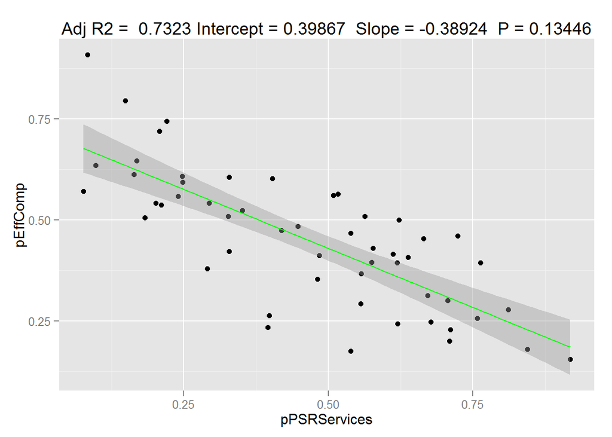

```r
ggplotRegression <- function (fit) {

require(ggplot2)

ggplot(fit$model, aes_string(x = names(fit$model)[2], y = names(fit$model)[1])) +
  geom_point() +
  stat_smooth(method = "lm", col = "green") +
  labs(title = paste("Adj R2 = ",signif(summary(fit)$adj.r.squared, 5),
                     "Intercept =",signif(fit$coef[[1]],5 ),
                     " Slope =",signif(fit$coef[[2]], 5),
                     " P =",signif(summary(fit)$coef[2,4], 5)))
}

ggplotRegression(zfit)
```

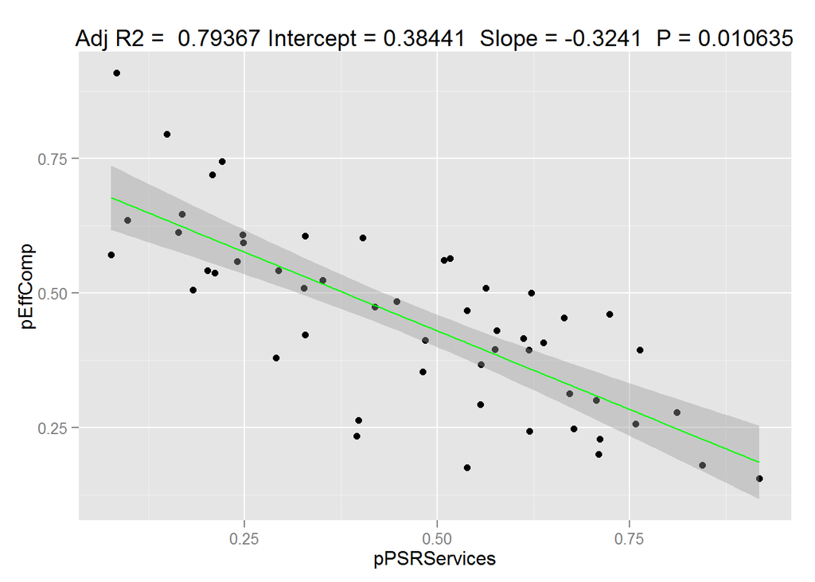

```r
ggplotRegression(afit)
```